# LabClass06

Nancy Lin

2022-10-14

Write out own **R functions**

Questions to answer:

> Q1. Write a function grade() to determine an overall grade from a vector of student homework assignment scores dropping the lowest single score. If a student misses a homework (i.e. has an NA value) this can be used as a score to be potentially dropped. Your final function should be adquately explained with code comments and be able to work on an example class gradebook such as this one in CSV format: “https://tinyurl.com/gradeinput” [3pts]

```r
# Example input vectors to start with
student1 <- c(100, 100, 100, 100, 100, 100, 100, 90)

student2 <- c(100, NA, 90, 90, 90, 90, 97, 80)

student3 <- c(90, NA, NA, NA, NA, NA, NA, NA)
```

Follow the guidelines from class - Write a working snipet of code that solves a simple problem

```r
# Straight forward mean ()
student1 <- c(100, 100, 100, 100, 100, 100, 100, 90)

mean(student1)
```

```
## [1] 98.75
```

But…. We need to drop the lowest score. First we need identify the lowest score.

```r
# Which element ofvector is the lowest?
which.min(student1)
```

```
## [1] 8
```

What i want is to now drop the lowest score from my mean calculation.

```r
# This will return everything but the eighth element of the vector
student1[-8]
```

```
## [1] 100 100 100 100 100 100 100
```

Now we can use the answer from which.min() to return all other elements of the vector

```r
# First working snippet
mean(student1[-which.min(student1)])
```

```
## [1] 100
```

Other student?

Try na.rm=TRUE ; Unfair

```r
student2 <- c(100, NA, 90, 90, 90, 90, 97, 80)
mean(student2, na.rm=TRUE)
```

```
## [1] 91
```

```r
student3 <- c(90, NA, NA, NA, NA, NA, NA, NA)
mean(student3, na.rm=TRUE)
```

```
## [1] 90
```

Replace all NA to 0

```r
student2 <- c(100, NA, 90, 90, 90, 90, 97, 80)
x <- student2
is.na(x)
```

```
## [1] FALSE  TRUE FALSE FALSE FALSE FALSE FALSE FALSE
```

```r
which(is.na(x))
```

```
## [1] 2
```

Now we want to “mask them” with 0

```r
student2 <- c(100, NA, 90, 90, 90, 90, 97, 80)
x <- student2
x[is.na(x)] <- 0
x
```

```
## [1] 100   0  90  90  90  90  97  80
```

```r
mean(x)
```

```
## [1] 79.625
```

We should drop the lowest score on top of it

```r
x[is.na(x)] <- 0
mean(x[-which.min(x)])
```

```
## [1] 91
```

Verify with student 3

```r
student3 <- c(90, NA, NA, NA, NA, NA, NA, NA)
x <- student3
x[is.na(x)] <- 0
mean(x[-which.min(x)])
```

```
## [1] 12.85714
```

## Now we make our function

Take the snippet and turn into function Every function have three parts

-name: ‘grade()’ -Input arguments, a vector of student scores -Body: code

Using Rstudio, it will select ‘Code > Extract Function’

```r
grade <- function(x) {
  x[is.na(x)] <- 0
  mean(x[-which.min(x)])
}
```

```r
grade(student1)
```

```
## [1] 100
```

```r
grade(student2)
```

```
## [1] 91
```

```r
grade(student3)
```

```
## [1] 12.85714
```

Great! Need to add comments to explain this to our future selves and others who want to use this function.

```r
#' Calculate the average score for a vector of
#' student scores dropping the lowest score.
#' Missing values will be treated as 0.
#'
#' @param x A numeric vector of homework scores
#'
#' @return  Average score
#' @export
#'
#' @examples
#' student <- c(100,NA,90,97)
#' grade(student)
grade <- function(x) {
  # mask NA with 0
  # Treat missing values as zero
  x[is.na(x)] <- 0
  # Exclude lowest score from mean
  mean(x[-which.min(x)])
}
```

Real world…

```r
url <- "https://tinyurl.com/gradeinput"
gradebook <- read.csv(url, row.names=1)
View(gradebook)
```

```r
apply(gradebook,1,grade)
```

```
##  student-1  student-2  student-3  student-4  student-5  student-6  student-7
##      91.75      82.50      84.25      84.25      88.25      89.00      94.00
##  student-8  student-9 student-10 student-11 student-12 student-13 student-14
##      93.75      87.75      79.00      86.00      91.75      92.25      87.75
## student-15 student-16 student-17 student-18 student-19 student-20
##      78.75      89.50      88.00      94.50      82.75      82.75
```

> Q2 Using your grade() function and the supplied gradebook, Who is the top scoring student overall in the gradebook? [3pts]

To answer this, we run the apply() fuction and save the results.

```r
results <- apply(gradebook,1,grade)
sort(results, decreasing= TRUE)
```

```
## student-18  student-7  student-8 student-13  student-1 student-12 student-16
##      94.50      94.00      93.75      92.25      91.75      91.75      89.50
##  student-6  student-5 student-17  student-9 student-14 student-11  student-3
##      89.00      88.25      88.00      87.75      87.75      86.00      84.25
##  student-4 student-19 student-20  student-2 student-10 student-15
##      84.25      82.75      82.75      82.50      79.00      78.75
```

```r
which.max(results)
```

```
## student-18
##         18
```

> Q3 From your analysis of the gradebook, which homework was toughest on students (i.e. obtained the lowest scores overall? [2pts]

```r
ave.scores <- apply(gradebook,2,mean, na.rm=TRUE)
ave.scores
```

```
##      hw1      hw2      hw3      hw4      hw5
## 89.00000 80.88889 80.80000 89.63158 83.42105
```

```r
which.min(ave.scores)
```

```
## hw3
##   3
```

```r
med.scores <- apply(gradebook,2,median, na.rm=TRUE)
med.scores
```

```
##  hw1  hw2  hw3  hw4  hw5
## 89.0 72.5 76.5 88.0 78.0
```

```r
which.min(med.scores)
```

```
## hw2
##   2
```

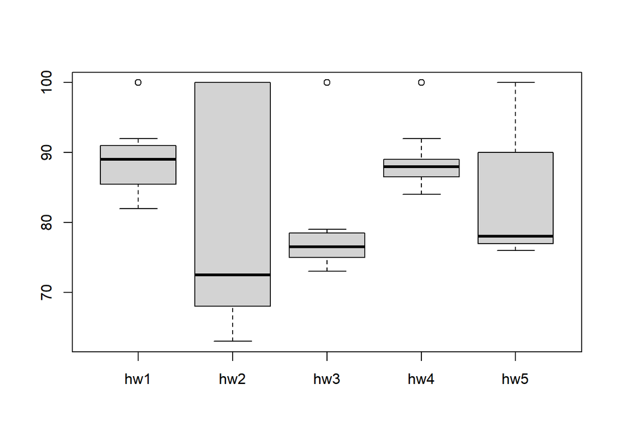

```r
boxplot(gradebook)
```

>Q4. Optional Extension: From your analysis of the gradebook, which homework was most predictive of overall score (i.e. highest correlation with average grade score)? [1pt]

Are tge final results correlated with the results for individual homeworks- the gradebook columns

```r
masked.gradebook <- gradebook
masked.gradebook[is.na(masked.gradebook)] <- 0

cor(results,masked.gradebook$hw5)
```

```
## [1] 0.6325982
```

```r
apply(masked.gradebook,2,cor,x=results)
```

```
##       hw1       hw2       hw3       hw4       hw5
## 0.4250204 0.1767780 0.3042561 0.3810884 0.6325982
```

> Q5. Make sure you save your Quarto document and can click the “Render” (or Rmarkdown” Knit”) button to generate a PDF foramt report without errors. Finally, submit your PDF to gradescope. [1pt]